# A Gentle Introduction to False Discovery Rate Multiplicity Adjustment Methods with R

Feb. 26, 2026

## About Me

- 2004: BS Math, Kansas State
- 2006: MS Statistics, Kansas State
- 2008: Married to Kate Allred
- 2010: PhD Statistics, University of South Carolina
- 2010: Assist. Professor, OSU Department of Statistics
- 2015: Max Habiger born
- 2021: Professor, Department of Statistics

Other things

- 3 cats (Marvin is my favorite) and a dog
- Basketball, Football, Tennis, Discgolf, Guitar/Piano

## Todays Objectives

1. Behind the scenes with a wheat microbiome data set
2. Productivity associated bacteria: False Discovery Rate adjustment
   - The classical approach
   - The empirical Bayes approach
3. FDR methods research questions
4. Recent and open student research
- Please do feel free to work through R code and play with it
  - https://jhabige.github.io/assets/FDR101.html
- Please do not presume code constitutes a thorough and sound analysis

## Part 1. Behind the Scenes

[figure not shown]

## Motivation

[Characterization and Identification of Productivity-Associated Rhizobacteria in Wheat. *Applied and Environmental Microbiology*, Anderson and Habiger (2012).](https://journals.asm.org/doi/10.1128/aem.07466-11)

From the Abstract: “The rhizosphere is populated by a numerous and diverse array of rhizobacteria, and many impact productivity in largely unknown ways… **Operational taxonomic units (OTUs) that were significantly associated with biomass productivity were *identified using an exact test adjusted for the false discovery rate***…”

## Importing and Checking

```r
url = "https://raw.githubusercontent.com/Jhabige/Jhabige.github.io/refs/heads/master/assets/bacteria.txt"
bacteria=read.table(url, row.names=1)
biomass=c(0.86, 1.34,1.81,2.37,3.0)
colnames(bacteria)= biomass
bacteria[1:5,]
```

```
##      0.86 1.34 1.81 2.37  3
## 1847    0    0    4   11 12
## 588     0    0    0    0 14
## 1697    0    0    4    1 13
## 1573    0    0    2    3  7
## 385     2    0    2    2 12
```

```r
dim(bacteria)
```

```
## [1] 778   5
```

- Shoot biomass \(\approx\) productivity measured for each sample
- p = 778 bacteria abundances measured per sample
- n = 5 samples
- p>n means **HIGH DIMENSIONAL** data

## Initial Boxplot: Skewed Right Data

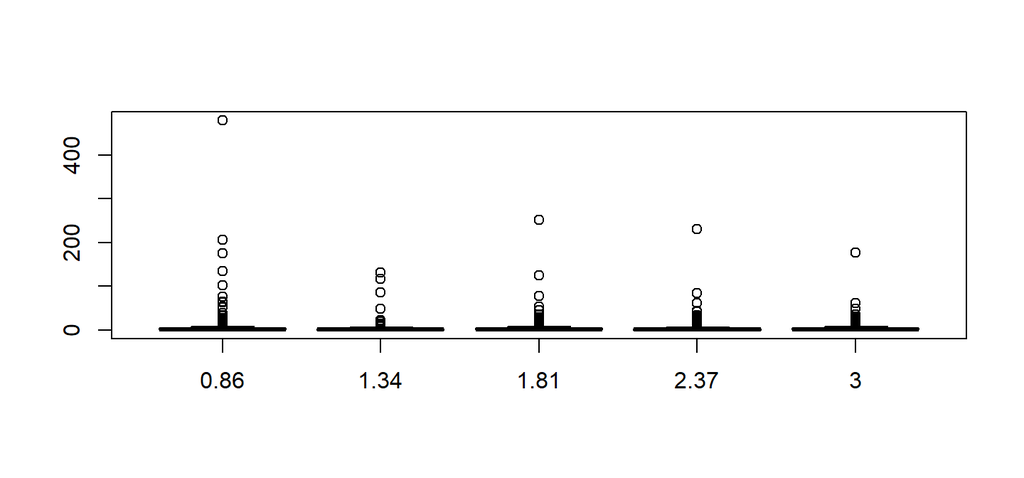

```r
boxplot(bacteria)
```

## Logged Data Boxplot: Better

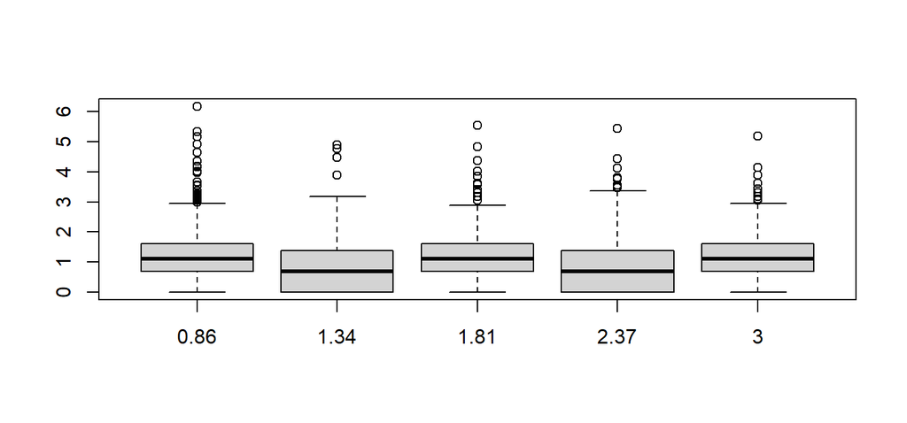

```r
l.bacteria=log(bacteria+1)
boxplot(l.bacteria)
```

## Biplot: Digging Deeper

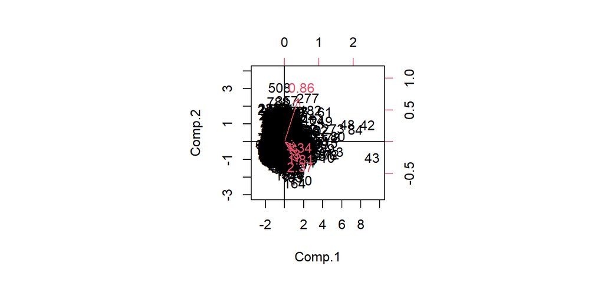

```r
biplot(princomp(l.bacteria), scale=0, ylim = c(-3,4), xlim = c(-3,10))
abline(h=0,v=0)
```

- Observe bacteria 508 (top) vs 42, 43 (right). Can we interpret?
- What are the arrows?

## Biplot Deets: Abundance and Association Components

```r
round(princomp(l.bacteria)$loadings[,1:2],2)
```

```
##      Comp.1 Comp.2
## 0.86   0.50   0.85
## 1.34   0.43  -0.09
## 1.81   0.47  -0.28
## 2.37   0.46  -0.39
## 3      0.37  -0.19
```

- **Points**: For each bacteria plug in its z score for X1, z score for X2, …
  - Z1 = .50 X1 + .43 X2 + .47 X3 + .46 X4 + .37 X5 (**abundance component**)
  - Z2 = .85 X1 - .09 X2 -.28 X3 -.39 X4 - .19 X5 (**association component**)
  - Can you interpret bacteria 508, 42, 43 on the biplot now?
- **Arrows**: Plots of loadings above

## Biomass vs Abundace for 3 Bacteria

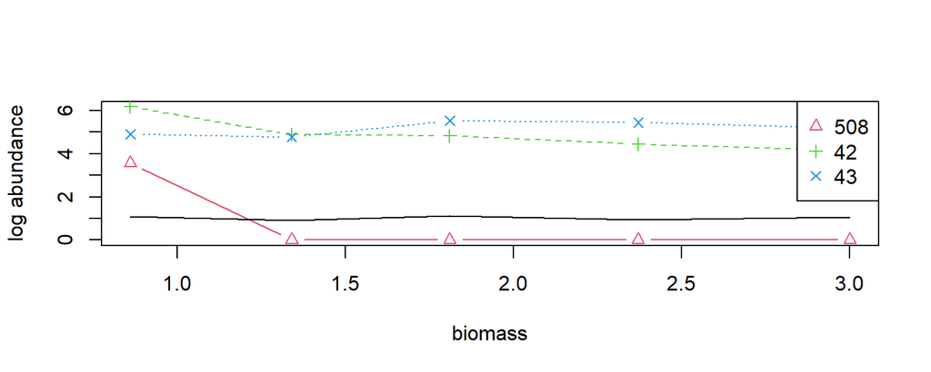

```r
interesting=c("508","42","43")
matplot(biomass,t(l.bacteria[interesting,]), pch = 2:4,col=2:4,type="b",ylab="log abundance")
legend("topright",pch=2:4, col=2:4,legend=interesting)
lines(biomass, colMeans(l.bacteria))
```

- Indeed 42, 43 are abundant
- Indeed 508 is negatively associated with biomass

## Assessing Biplot

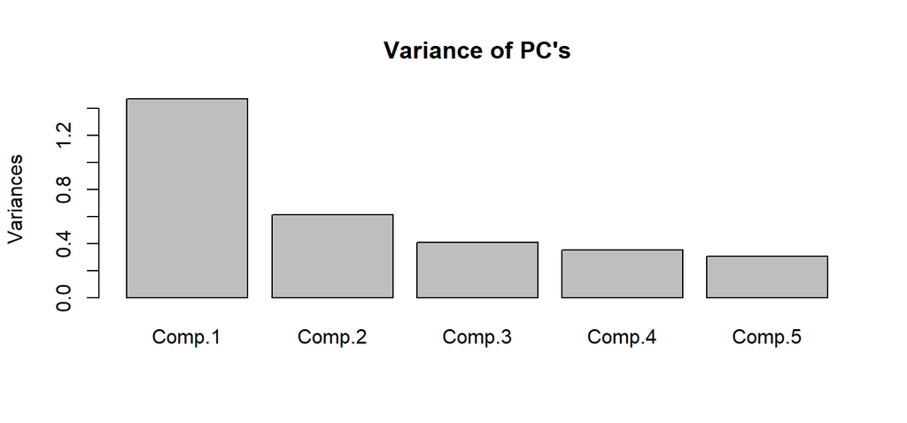

```r
plot(princomp(l.bacteria), main = "Variance of PC's")
```

- **Abundance variation (Z1)** and **Productivity associated variation (Z2)**
- Comp.3 - Comp.5 variation not on biplot!

## Question: Standardize?

- In Principle Component Analysis:
  - Z1 and Z2 are linear combinations of X1,..,X5 that maximize **variance**
  - Typically PCA is ran after centering and scaling **variables** to have mean 0 and standard deviation 1.
    - This way **unit of measure** doesn’t matter
    - Not necessary if variables on same scale
- **Important**: Here we ran PCA on **samples**
  - Are samples already on “the same scale”, i.e. “technical variation”?
  - If yes, PCA results won’t change after scaling

## Before Scaling

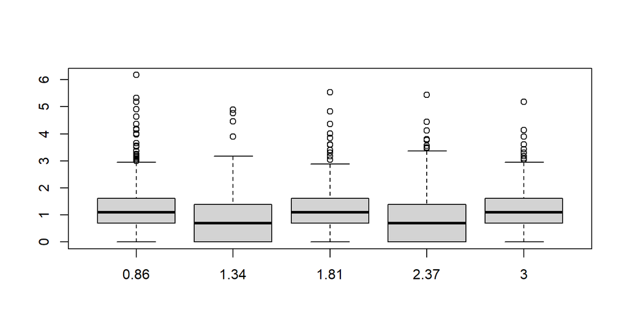

```r
boxplot(l.bacteria)
```

## After Scaling

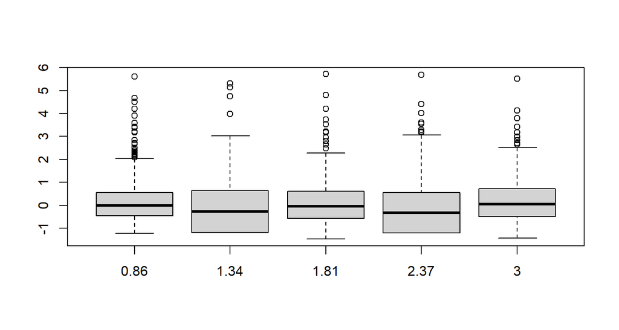

```r
sl.bacteria = scale(l.bacteria)
boxplot(sl.bacteria)
```

## Before Scaling

```r
round(princomp(l.bacteria)$loadings[,1:2],2)
```

```
##      Comp.1 Comp.2
## 0.86   0.50   0.85
## 1.34   0.43  -0.09
## 1.81   0.47  -0.28
## 2.37   0.46  -0.39
## 3      0.37  -0.19
```

## After Scaling

```r
round(princomp(sl.bacteria)$loadings[,1:2],2)
```

```
##      Comp.1 Comp.2
## 0.86   0.37   0.87
## 1.34   0.46   0.13
## 1.81   0.50  -0.22
## 2.37   0.48  -0.36
## 3      0.41  -0.23
```

## Before Scaling

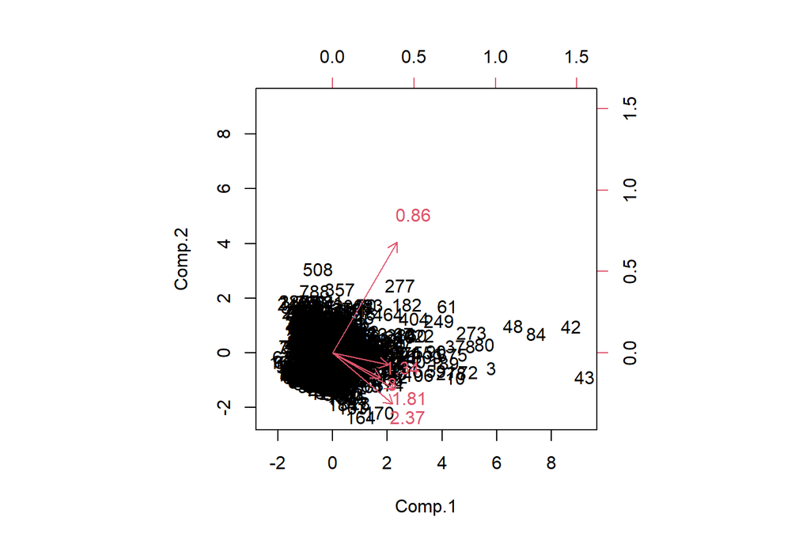

```r
biplot(princomp(l.bacteria), scale=0)
```

## After Scaling

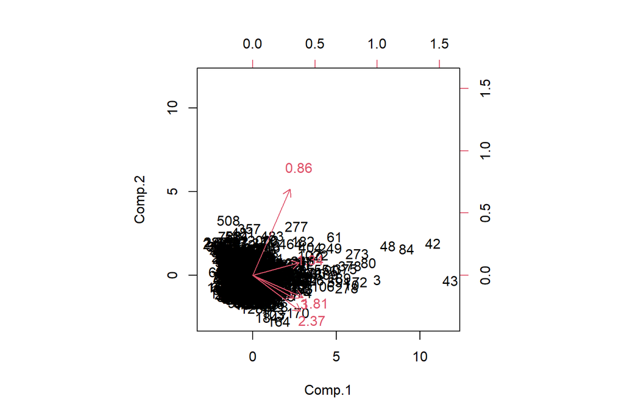

```r
biplot(princomp(sl.bacteria), scale = 0)
```

## Before Scaling

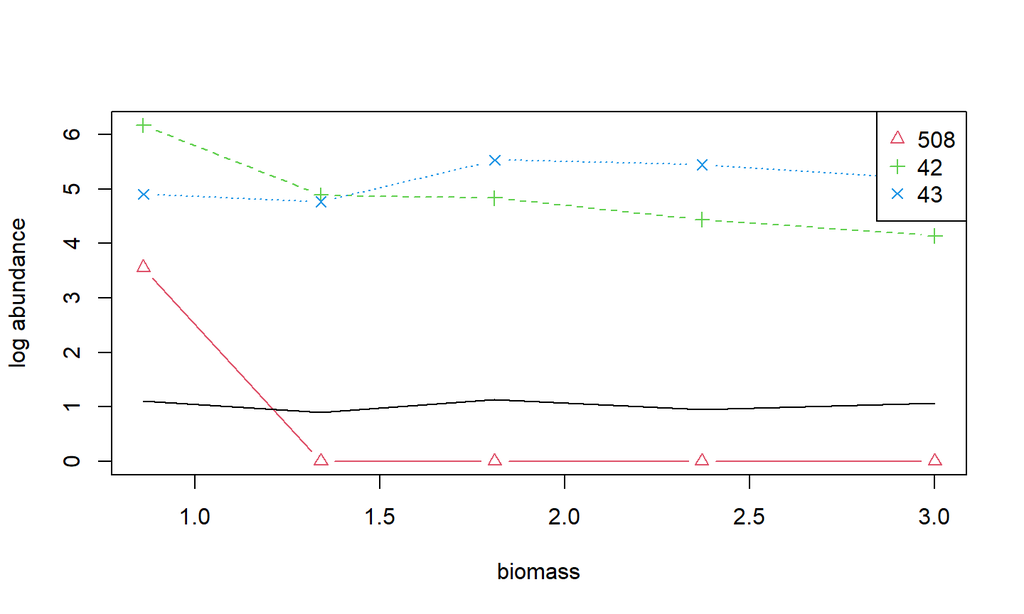

```r
matplot(biomass,t(l.bacteria[interesting,]), pch =2:4,col=2:4,type="b",ylab="log abundance")
legend("topright",pch=2:4, col=2:4,legend=interesting)
lines(biomass, colMeans(l.bacteria))
```

## After Scaling

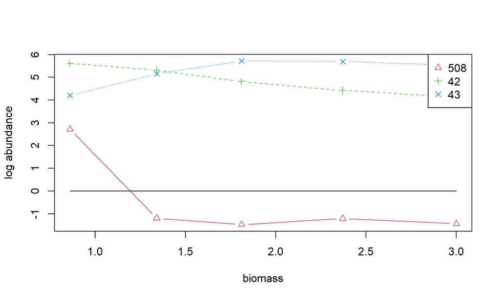

```r
matplot(biomass,t(sl.bacteria[interesting,]), pch = 2:4,col=2:4,type="b",ylab="log abundance")
legend("topright",pch=2:4, col=2:4,legend=interesting)
lines(biomass, colMeans(sl.bacteria))
```

## Which Bacteria are Associated?

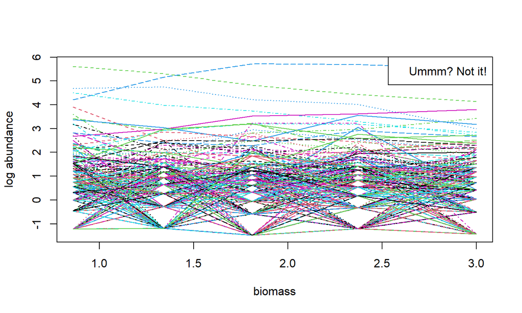

```r
matplot(biomass,t(sl.bacteria),type="l",ylab="log abundance")
legend("topright",legend="Ummm? Not it!")
```

## Part 2: False Discovery Rate Adjustment

## Two Types of FDR Estimates

The False Discovery Rate (FDR) is \[FDR = E\left[\frac{\# \text{ False Discoveries}}{\#\text{ Discoveries} }\right]\]

1. **Specify statistical model** and null hypotheses
2. Compute p-values (classical approach) \(p_1,p_2,..,p_M\) or posterior null probabilities (empirical Bayes approach) \(q_1,q_2,...,q_M\)
3. Use statistics above to estimate FDR or “adjust” for FDR
- [Classical (BH procedure) estimate](https://rss.onlinelibrary.wiley.com/doi/10.1111/j.2517-6161.1995.tb02031.x): \(\widehat{FDR}(p_{(k)}) = \frac{M p_{(k)}}{k}\)
- [Empirical Bayes estimate](https://www.tandfonline.com/doi/abs/10.1198/016214507000000545): \(\widehat{FDR}(q_{(k)}) = \frac{1}{k}\sum_{i=1}^k q_{(i)}\)

## Example: Classical Approach

```r
pvalues=rep(NULL, 778)
lfc=rep(NULL, 778)
bacteria = as.matrix(bacteria)
for(i in 1:778){
  #1. Specify model
  model=summary(glm(bacteria[i,]~biomass, family="poisson"))
  #2. Compute p-values (and LFC while we're at it)
  pvalues[i]=model$coefficient[2,4]
  lfc[i]=model$coefficient[2,1]
}
```

[output not shown]

- Above gets p-values and log fold changes (more later) for log linear model
- Yes warnings can and will happen in even **simple generalized linear model**
  - MLE’s for glm’s require algorithm to converge

## Example: Classical Approach Cont

```r
# 3. Estimate FDR and return TRUE if < .05
discoveries = p.adjust(pvalues, method = "BH")<.05
sum(discoveries)
```

```
## [1] 34
```

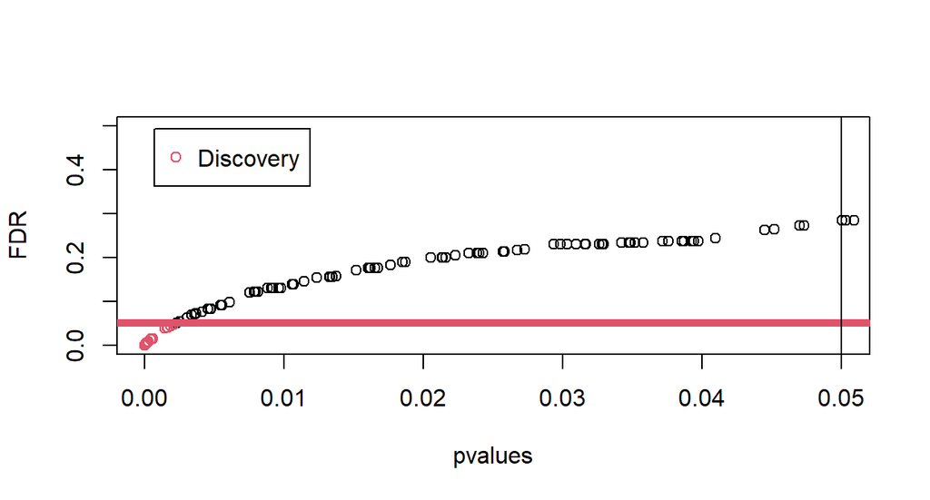

```r
plot(pvalues, p.adjust(pvalues, method="BH"), ylab="FDR", xlim = c(0,.05),ylim=c(0,.5), col= as.numeric(discoveries)+1)
abline(h = 0.05,v=.05, lwd =c(5,1), col = c(2,1))
legend("topleft", inset=.05, col=2, pch=1, legend = "Discovery")
```

## Q: Why Not p < .05?

- Q: How many discoveries would be made for P<.05 rule?

```r
sum(pvalues<.05)
```

```
## [1] 135
```

- Q: How many **false discoveries** would be anticipated for P<.05 rule?

```r
778*0.05
```

```
## [1] 38.9
```

- Q: What is the FDR of for P<.05 rule? Is it acceptable?

```r
38.9/135
```

```
## [1] 0.2881481
```

## Q: Why Not Bonferroni?

- Bonferroni procedure uses \(P<.05 / 778\) and controls Family-Wise Error Rate (FWER)
- Q: How many discoveries would be made using Bonferroni rule?

```r
sum(pvalues<.05/778)
```

```
## [1] 17
```

- Q: What are the differences in interpretations and “scalability” for FDR and FWER

## Example: Empirical Bayes Approach

```r
#1. Priors pi, beta estimated in Habiger, Watts, Anderson (2017)
pi = c(.69,.16,.15)
beta=c(0,-1.13,.78)

#2 Compute posterior:
p.0=exp(beta[1]*biomass)/sum(exp(beta[1]*biomass))
p.l=exp(beta[2]*biomass)/sum(exp(beta[2]*biomass))
p.u=exp(beta[3]*biomass)/sum(exp(beta[3]*biomass))
q<-function(y){ pi[1]*dmultinom(y,prob=p.0)/
 (pi[1]*dmultinom(y,prob=p.0) + pi[2]*dmultinom(y,prob=p.l)+pi[3]*dmultinom(y, prob=p.u))}
qs=rep(NULL, 778)
for(i in 1:778){qs[i]=q(bacteria[i,])}
```

- Notable differences in steps 1 and 2
  - Specified pi and beta values
  - Had to use Bayes theorem and my own code to compute \(q\) - not using glm()

## Example: Emp. Bayes Approach cont.

```r
#3 EBdiscoveries are ones with FDR<.05
s.q=sort(qs)
FDR=cumsum(s.q)/1:778
k=sum(FDR<=.05)
EBdiscoveries=qs<=s.q[k]
sum(EBdiscoveries)
```

```
## [1] 97
```

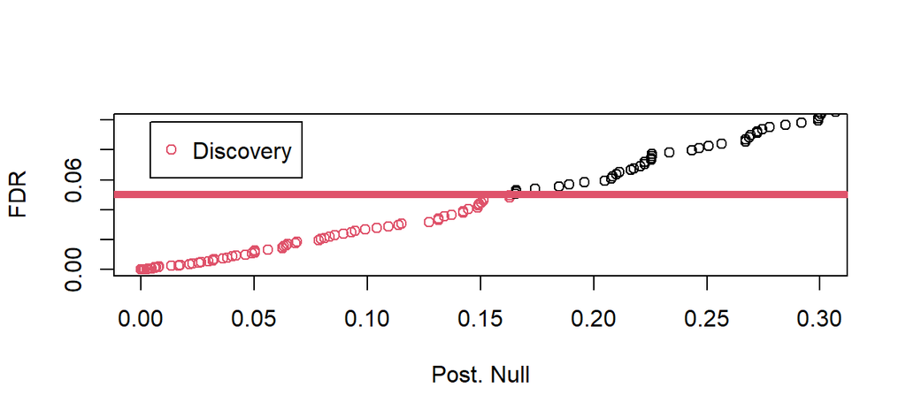

```r
plot(s.q, FDR, xlab="Post. Null", ylab = "FDR", xlim = c(0,.3), ylim = c(0, .1), col=I(FDR<.05)+1)
abline(h = 0.05, lwd =5, col = 2)
legend("topleft", inset=.05, col=2, pch=1, legend = "Discovery")
```

## Before FDR Adjustment

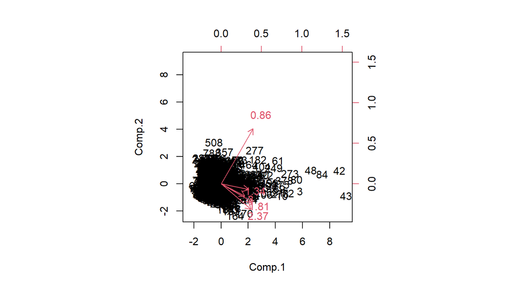

```r
biplot(princomp(l.bacteria[,]),scale=0)
```

## After Classical FDR Adjust.

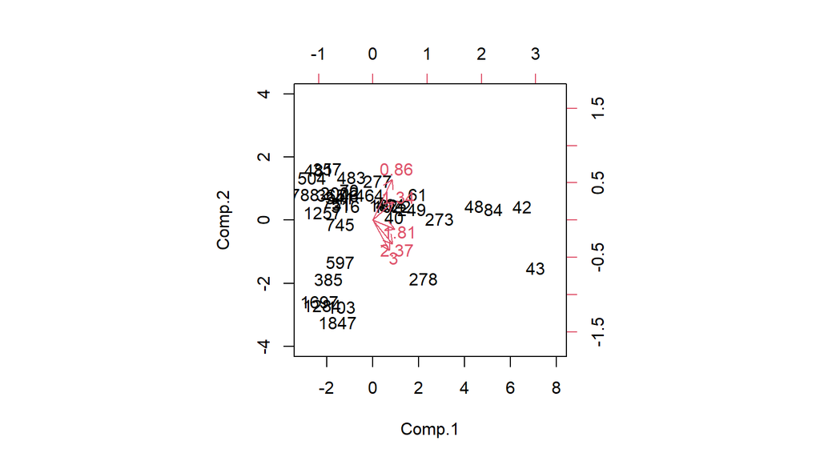

```r
biplot(princomp(l.bacteria[discoveries,]),xlim = c(-3,8),ylim = c(-4, 4),scale=0)
```

## After Emp. Bayes FDR Adjust.

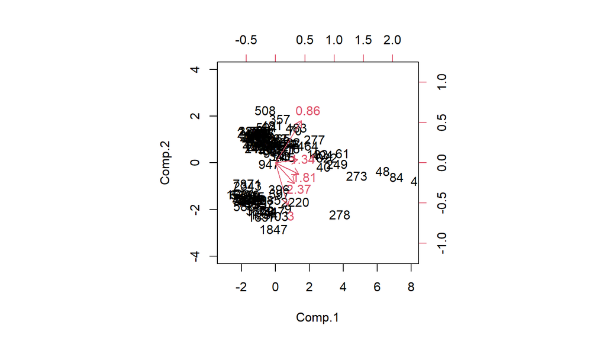

```r
biplot(princomp(l.bacteria[EBdiscoveries,]),xlim = c(-3,8),ylim = c(-4, 4), scale=0)
```

## Classical vs. Emp. Bayes Adjust.

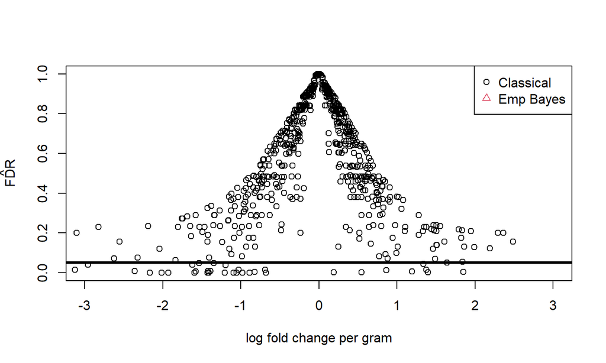

```r
plot(lfc,p.adjust(pvalues, method="BH"), xlim = c(-3,3), xlab = "log fold change per gram", ylab=expression(hat(FDR)))
abline(h=0.05, lwd =3)
#index=sort(qs, index=TRUE)[[2]]
#points(lfc[index], FDR,pch=2, col=2)
legend("topright",legend=c("Classical","Emp Bayes"), pch = c(1,2), col = c(1,2))
```

## Classical vs. Emp. Bayes Adjust.

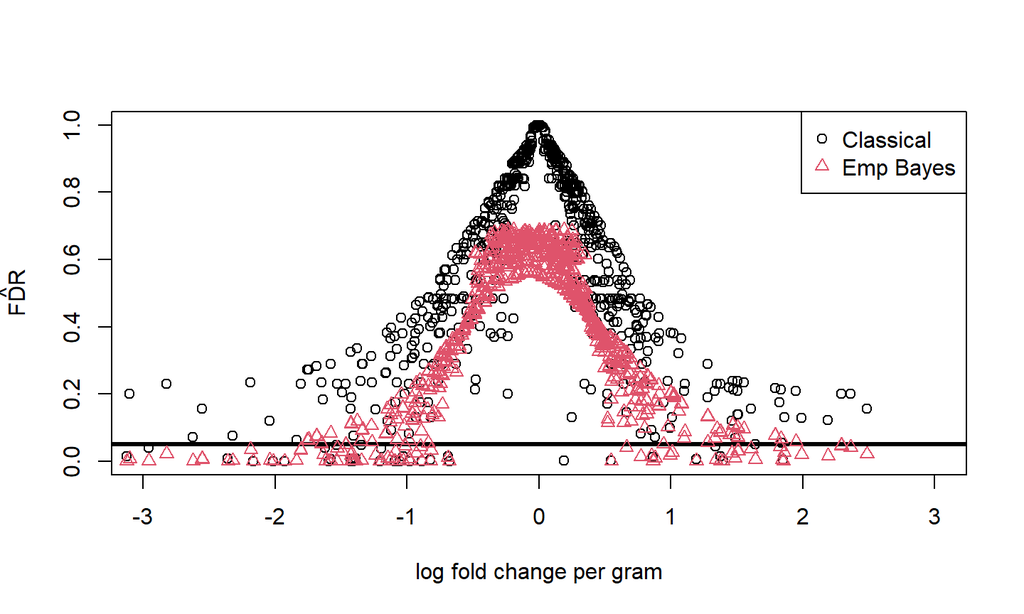

```r
plot(lfc,p.adjust(pvalues, method="BH"), xlim = c(-3,3), xlab = "log fold change per gram", ylab=expression(hat(FDR)))
abline(h=0.05, lwd =3)
index=sort(qs, index=TRUE)[[2]]
points(lfc[index], FDR,pch=2, col=2)
legend("topright",legend=c("Classical","Emp Bayes"), pch = c(1,2), col = c(1,2))
```

## Part 3: FDR Methods Research

## Classical FDR Research Questions

- Properties: BH procedure controls the FDR **If P-values are valid** and, say, positively correlated.
- Step 1. glm() function specified Poisson model and \(H_0:\) LFC\(_i=0\) (the log fold change per biomass gram for bacteria \(i\))
- What about models for…
  - **Over-dispersion**: Try adding “family = quasipoisson” to glm(), or using nb.glm(), chisq.test(), lm() on logged data. Do you get the same results?
  - **Zero-inflation**: Recall lots of zeros for some bacteria
  - **Normalization**: Try glm(bacteria[i,]~biomass + colSums(bacteria),..). Do you get the same results? Why not median, etc.
- Why \(H_0:\) LFC\(_i = 0\) and why not \(H_0:\) LFC\(_i\approx 0\)?

## Classical FDR Research Questions

- Step 2. Get \(Z_i = \widehat{\text{LFC}}_i/SE_i\) and \(P_i=\Pr_0(|Z_i|\geq |z_i|)\)
- P-values are valid if we use the **correct distribution** in \(\Pr_0\).
  - Is Z\(\sim\) N(0,1) used in glm “correct”?
  - **Over/under fitting** and **bias vs. variance**:
    - Why not just use those some of the previous models?
- We can prove standard errors (and p-values) go to 0 as total abundance increases…**EVEN IF LFC\(_i = 0.000001\)** in reality!
  - Do \(H_0:\) LFC\(_i\approx 0\) and \(H_0:\) LFC\(_i=0\) agree here?
  - Who cares?

## Fred’s is Abundant, NOT Productive!

[figure not shown]

Statistics Show Fred is Associated with Productivity!

## Classical FDR Research Questions

- Step 3. Compute \(\widehat{FDR}(p) = \frac{M p}{(\# p_i\leq p)}\) for each \(p\).
- The numerator estimates # False Discoveries as M \(p\).
  - Is that conservative?
- Can we use \(SE_i\) in **weighted** p-value procedures?
  - How can we choose weights?
  - How should criteria, data, etc. inform other weights

## Empirical Bayes Research Questions

- Properties: Empirical Bayes procedures **should** (asymptotically) control the FDR and [make more discoveries than classical approach counterparts](https://www.tandfonline.com/doi/abs/10.1198/016214507000000545)
- Step 1. Assume **3 possible multinomial distributions** and \(H_0:\)LFC\(_i=0\)
- **Parameter Estimation**: Maximum likelihood estimators below. Other types?
  - LFC\(_i\) = 0 with probability 0.69,
  - LFC\(_i\) = -1.13 with probability 0.16,
  - LFC\(_i\) = .78 with probability 0.15
- **Statistical Model**: Why 3 multinomials? Why multinomial? These choices affect
  - Over-dispersion
  - Zero-inflation
  - Over/under fitting and bias vs variance
- Is \(H_0:\) LFC\(_i = 0\) or \(H_0:\) LFC\(_i\approx 0\) tested in above considerations?

## Empirical Bayes Research Questions

- Step 2. Estimate **posterior null probability** \(q_i = \Pr(LFC_i=0|\text{Bacteria}_i)\)
- Are posterior null probabilities approximately “valid”?
  - Over/under fitting, over-dispersion, zero-inflation
  - Number of multinomials \(k\) “tunes” bias vs variance / over-under fitting
- Is \(q_i\) the same for \(H_0:\) LFC\(_i\approx 0\) vs \(H_0:\) LFC\(_i=0\)?
  - Does number of multinomials (k=3, 5, 10,…) matter?
  - Does “\(\approx\)” matter?
  - Can Fred become “significant” for some \(k\) and “\(\approx\)” definitions?

## Empirical Bayes Research Questions

- Step 3. Estimate \(FDR(q_{(r)}) = \bar{q}\)
- We could prove that **ANY DISCOVERY RULE** with \(\bar{q}\leq \alpha\) controls FDR!
- Standard procedure maximize the number of discoveries
- Quantity vs quality?
  - How to measure “quality”

## Empirical Bayes vs Classical

- Why is the [Benjamini and Hochber (1995) procedure](https://rss.onlinelibrary.wiley.com/doi/10.1111/j.2517-6161.1995.tb02031.x) one of the most [highly cited statistics papers of all time](https://www.youtube.com/watch?v=ZGU4SlE9Pu8)?
  - Better than Bonferroni, especially when num tests is large
  - We can get usually get a p-value for quite complex models
  - Presume p-value is valid
- When to use an Empirical Bayes methods?
  - You know how to select a good model and null hypotheses
  - You know how to estimate parameters well

## Part 4: Recent and Open Student Research

## Emmanuel Asare (PhD 2025)

- Multiple Testing Procedures for Count Data Based on the Local False Discovery Rate. Asare, Habiger, Rudra (2026+). R Package [PMLfdr](https://github.com/ekaasare/PMLfdr/)

|  | Deseq2, EdgeR | PMLfdr |
| --- | --- | --- |
| Approach | P-value | Empirical Bayes |
| Overdispersion | YES | YES + formula! |
| Over/Under Fitting | YES | YES + model selection |
| FDR Control/Efficiency | simul/no | proof+simul / proof+simul |
| Is Fred Productive | YES | NO |
| Misuse Potential | Low | Moderate |

## Other Related Student Research

With Prof Rudra and Mehedi Hassan (PhD 2028): Empirical Bayes Methods for false discovery rate control

- Poisson mixtures vs. Multinomial mixtures?
- Affect of normalization methods in above?
- Include other covariates in model?

Victor Abadom (MS 2026):

- When will \(\text{log}(Y+1) \sim N(\mu,\sigma^2)\) work well vs. \(Y\sim\) Negative Binomial, quasi-Poisson, etc.?
- What about zero inflation?

## Potential Stat Student Research

- Rhizosphere-Mediated Effects on Winter Wheat Yield in Oklahoma and the Development of Diagnostic Probes Targeting Beneficial Microorganisms. Ramos-Lopez, Espindola, et. al. (2026+)
  - Model: log_Abun\(_i\sim\beta_{0i} +\beta_{1i} f(\text{Phenotype}_{1i},..., \text{Phenotype}_{5i})\)
    - \(f()\) indicates high yield
    - 12 trt groups (Soil x Variety x Feek Stage) + 3 sampling depths
  - [HD replicability analysis](https://projecteuclid.org/journals/statistical-science/volume-38/issue-4/Replicability-Across-Multiple-Studies/10.1214/23-STS892.pdf) could be used to identify bacteria differentially expressed in \(2\) + groups, \(3\) + groups, . . . ?
  - [HD mediation analysis](https://pmc.ncbi.nlm.nih.gov/articles/PMC7263455/) could be used to identify which bacteria are mediating relationships between factors and yield?
- Challenges: EVERYTHING WE JUST TALKED ABOUT and
  - HD replicability and HD mediation not well developed
  - specification/estimation of \(f\).

## Huizi Wang (PhD 2026)

- Efficient Classification Methods for Sparse High-Dimensional Count Data with Model Selection as Motivated by Microbe Finder. Wang, Habiger, Espindola, Cardwell (2026+)

\[\text{logit}(\Pr(\text{Pathogen})) = \beta_1 EP_1 + \beta_2 EP_2 + ... +\beta_{1000} EP_{1000}\]

- Competing Methods:
  - Logistic Regression with LASSO penalty (glmnet in R)
  - Quadratic Discriminant Analysis on total \(\approx\) EP1 +…+ EP1000
  - Poisson Linear Discriminant Analysis with soft thresholding penalty
- Huizi’s method and contributions:
  - Add dummy variables to model **zero-inflation**
  - MOM estimates **avoid iterative procedures** and include **over-dispersion**
  - Use soft thresholding (LASSO ish) to shrink and **select Eprobes**
- **FDR control**?

## Chase Cao (PhD 2024)

- Sensitivity Analysis for FDR Estimation Under Misspecified Selection Model. Cao, Yi, Habiger (2026+)
- Motivation
  1. Ioannidis: [Why Most Published Research Findings are False](https://doi.org/10.1371/journal.pmed.0020124) - sciencewide FDR!
  2. ASA (ish) [statement on p-values](https://doi.org/10.1080/00031305.2016.1154108) blames \(p\)-value misuses for replication crisis
  3. Benjamini clarifies that its [Selective Inference: The Silent Killer of Replicability](https://hdsr.mitpress.mit.edu/pub/l39rpgyc/release/3)
- Working **Selective Inference** model for science
  1. All “data” in some “population”
  2. **Selection mechanism** say \([P<.05]\) yields observable data
  3. Estimate science-wide FDR with selected data under this model
- Question: Is selection mechanism really that simple? What if we’re wrong?

## Thanks

### Thanks to all collaborators at OSU and students!

- Michael Anderson et. al.
- Andres Espindola et. al.
- Kitty Cardwell et. al.
- many more

### More info

- https://jhabige.github.io/
- https://experts.okstate.edu/jhabige
- https://jhabige.github.io/pictures/

## Courses: Happy to Provide Advice

- Courses of interest that I teach
  - R Programming STAT 5191 or STAT 5193
  - **Statistical Machine Learning with R STAT 5063**
  - **Computational Statistics STAT 5093 (need some MS level Math STAT)**
  - BRING YOUR DATA!
- Recommended Analytics sequence for non-stat majors
  - R Programming STAT 5191 (or SAS and R - STAT 5193) - maybe skip
  - Applied Regression Analysis STAT 5543
  - **Statistical Machine Learning with R STAT 5063**
- Recommended Experimental Data Analysis sequence for non-stat majors
  - SAS programming (or SAS and R - STAT 5193) - mabye skip
  - **Statistics for Experimenters II STAT 5023**
  - Experimental Designs STAT 5303